# NFL 2020 Week 21

# Cadet Individual Results

MA206 Individual Results

Week 21

Name

Weekly # Correct

Percent

Weeks Picked

Season Percent

Adj Season Percent

Season Trend

Week 1

Week 2

Week 3

Week 4

Week 5

Week 6

Week 7

Week 8

Week 9

Week 10

Week 11

Week 12

Week 13

Week 14

Week 15

Week 16

Week 17

Week 18

Week 19

Week 20

Week 21

Luca Testa

NA

NA

10

NA

NA

NA

NA

NA

NA

NA

NA

NA

NA

NA

NA

NA

NA

NA

NA

NA

1

1

2

0.6875

0.0655

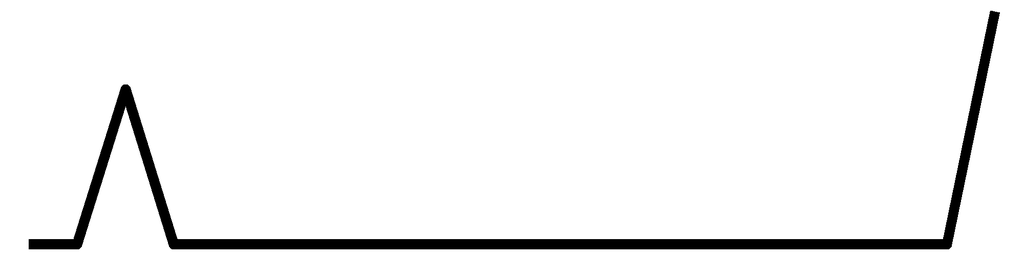

John White

10

11

10

8

12

9

11

6

9

9

8

10

8

11

10

10

12

6

2

1

1

1

21

0.6566

0.6566

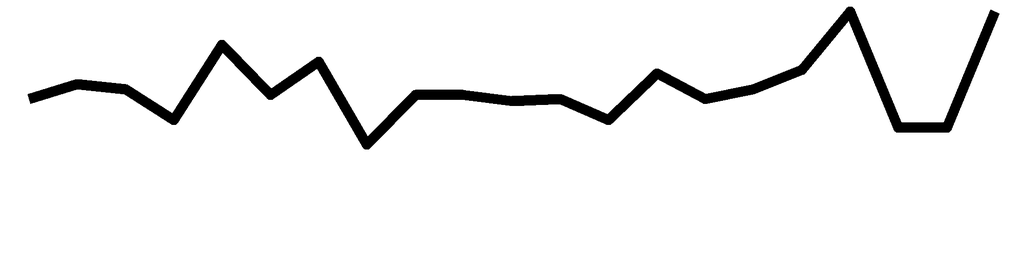

Gabriela Peralta

11

8

9

NA

8

8

10

6

NA

8

6

10

12

NA

12

NA

NA

4

3

1

1

1

16

0.6158

0.4692

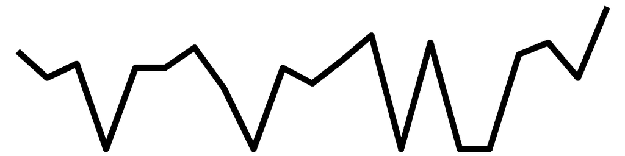

Sidney Cash

10

10

NA

10

NA

8

8

7

11

8

5

10

10

8

NA

NA

NA

NA

NA

2

1

1

14

0.6034

0.4023

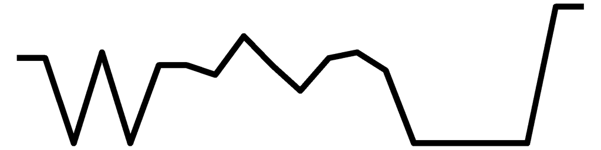

Caroline Swenson

8

12

11

13

7

8

10

NA

8

9

8

NA

12

11

12

8

13

4

3

1

0

0

19

0.6723

0.6083

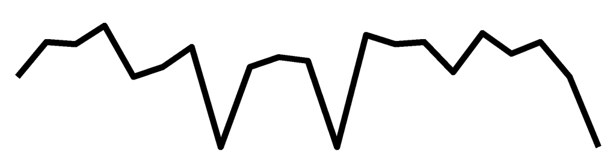

Paige Lennon

NA

NA

NA

11

10

8

11

8

6

8

6

9

11

10

11

NA

NA

NA

NA

NA

0

0

13

0.6229

0.3856

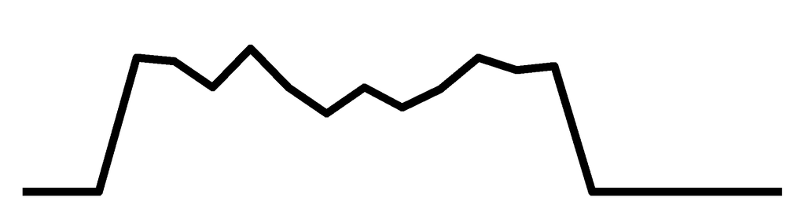

Sydney Shannon

10

9

8

9

8

7

9

5

8

10

8

10

11

10

11

12

12

4

3

1

0

0

21

0.6226

0.6226

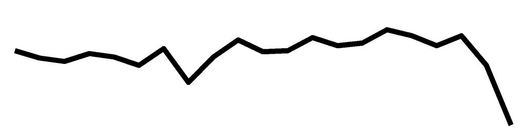

Thomas Bizub

10

14

8

11

8

9

10

8

10

12

9

11

9

10

NA

NA

NA

NA

NA

NA

NA

0

14

0.6780

0.4520

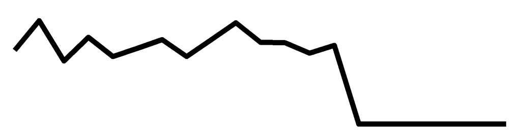

Amadou Bah

9

NA

NA

NA

NA

NA

NA

NA

NA

NA

NA

NA

NA

NA

NA

12

NA

NA

NA

NA

NA

0

2

0.6774

0.0645

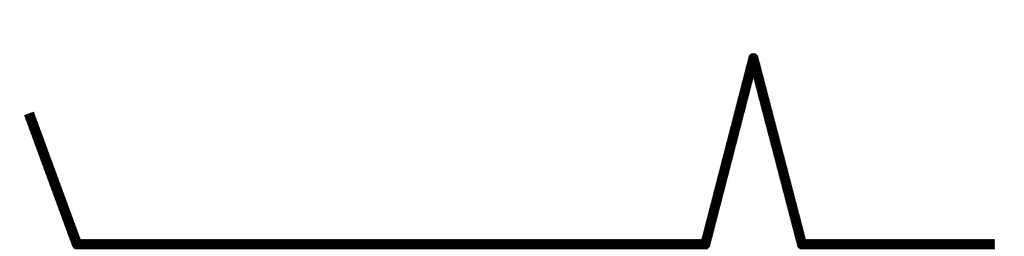

Kieran Place

12

11

8

NA

10

10

9

NA

NA

NA

NA

NA

NA

NA

NA

NA

NA

NA

NA

NA

NA

0

6

0.6742

0.1926

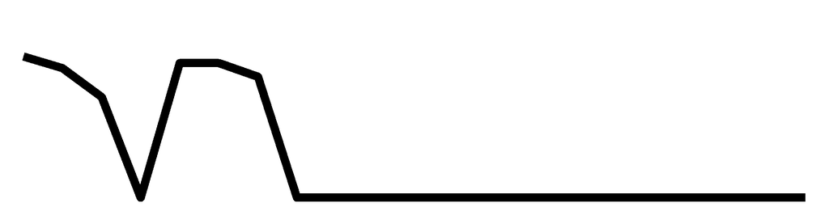

Laurence Dowd

10

10

10

9

10

NA

12

NA

10

8

7

NA

10

NA

NA

NA

NA

NA

NA

NA

NA

0

10

0.6575

0.3131

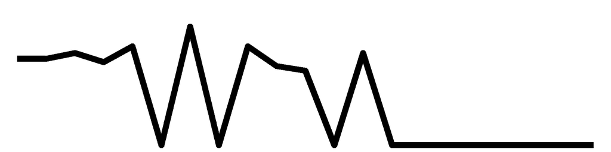

Joshua Loyd

11

9

8

NA

6

9

NA

6

10

8

NA

10

9

11

12

12

13

3

NA

NA

NA

0

15

0.6343

0.4531

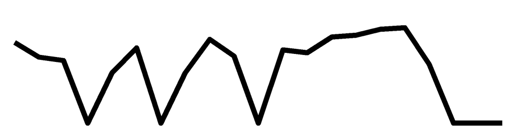

Jonathan Kemp

10

10

NA

NA

11

10

11

7

8

6

8

12

8

9

NA

NA

NA

NA

NA

NA

NA

0

12

0.6286

0.3592

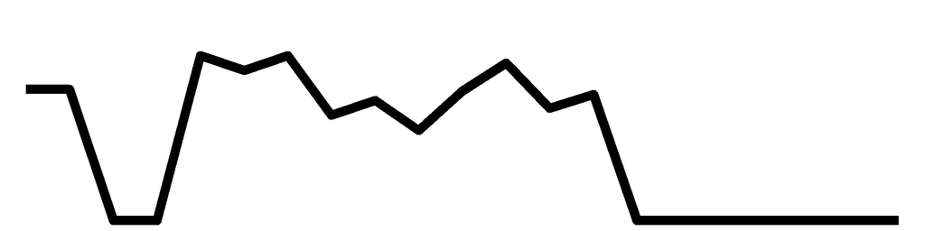

Zakai Bufkin

8

11

7

9

8

10

9

7

9

9

NA

10

NA

NA

NA

12

NA

NA

NA

NA

NA

0

12

0.6158

0.3519

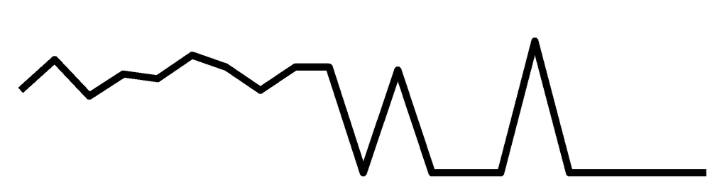

Christopher Erb

9

9

7

11

9

11

8

11

10

9

5

10

9

8

NA

NA

NA

NA

NA

NA

NA

0

14

0.6146

0.4097

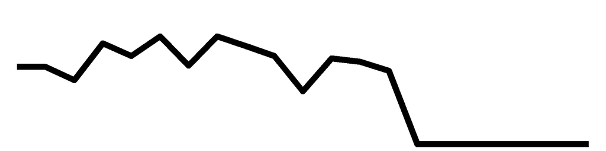

Victor Olawale-Apanpa

8

NA

10

NA

10

NA

10

7

7

9

6

11

10

NA

NA

NA

NA

NA

NA

NA

NA

0

10

0.6069

0.2890

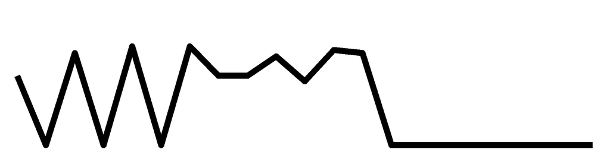

Cameron Patterson

11

9

8

NA

NA

NA

NA

NA

NA

NA

NA

NA

NA

NA

NA

NA

NA

NA

NA

NA

NA

0

3

0.5957

0.0851

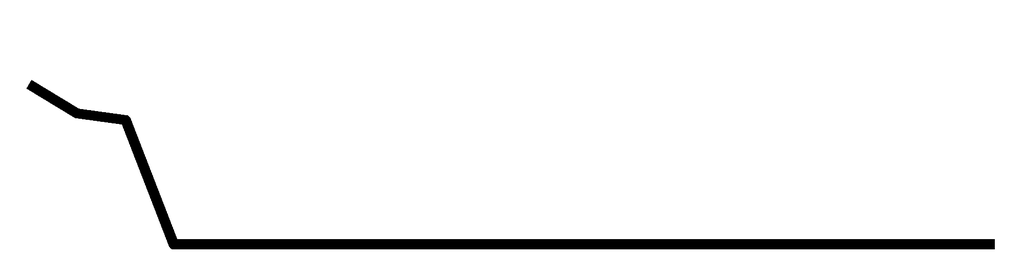

Joshua Gilliard

9

8

9

10

10

7

10

7

5

8

NA

10

10

NA

NA

NA

NA

NA

NA

NA

NA

0

12

0.5819

0.3325

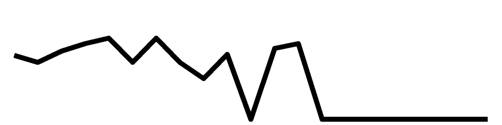

Margaret Williams

9

NA

NA

NA

NA

NA

NA

NA

NA

NA

NA

NA

NA

NA

NA

NA

NA

NA

NA

NA

NA

0

1

0.5625

0.0268

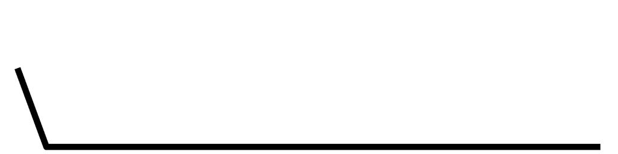

Logan Kauina

9

NA

NA

NA

NA

NA

NA

NA

NA

NA

NA

NA

NA

NA

NA

NA

NA

NA

NA

NA

NA

0

1

0.5625

0.0268

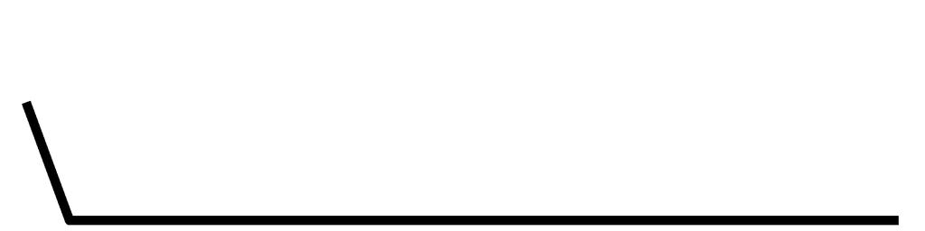

Caleb John

NA

9

NA

NA

NA

NA

NA

NA

NA

NA

NA

NA

NA

NA

NA

NA

NA

NA

NA

NA

NA

0

1

0.5625

0.0268

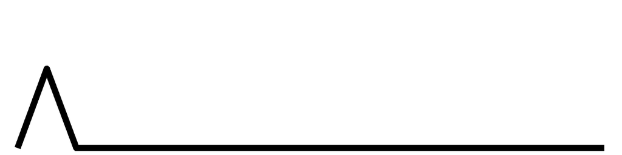

Jay Hajost

11

7

10

NA

6

NA

NA

7

9

NA

NA

NA

NA

NA

NA

NA

NA

NA

NA

NA

NA

0

6

0.5618

0.1605

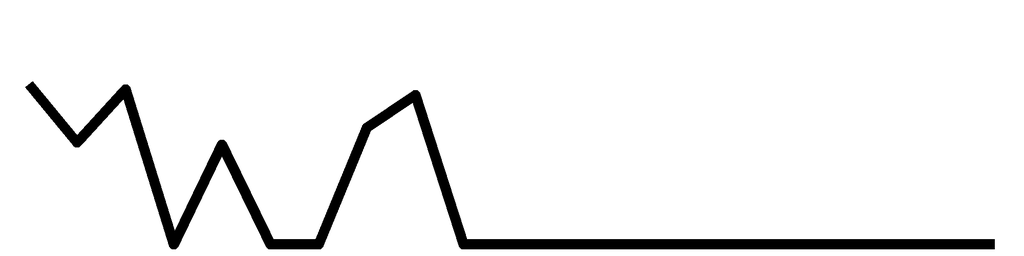

Ryan Jackovic

11

10

NA

7

7

8

8

7

NA

4

5

NA

12

10

NA

NA

NA

NA

NA

NA

NA

0

11

0.5562

0.2913

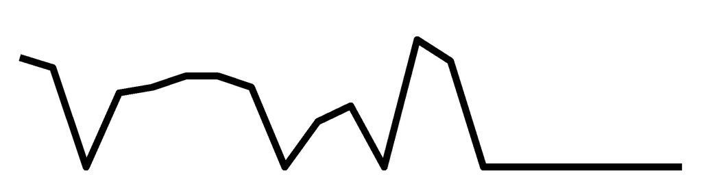

August Rannow

9

NA

NA

NA

7

NA

NA

NA

NA

NA

NA

NA

NA

NA

NA

NA

NA

NA

NA

NA

NA

0

2

0.5333

0.0508

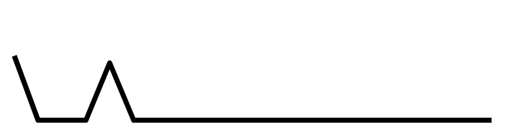

Peter Digenan

9

6

8

10

7

NA

NA

NA

NA

NA

NA

NA

NA

NA

NA

NA

NA

NA

NA

NA

NA

0

5

0.5263

0.1253

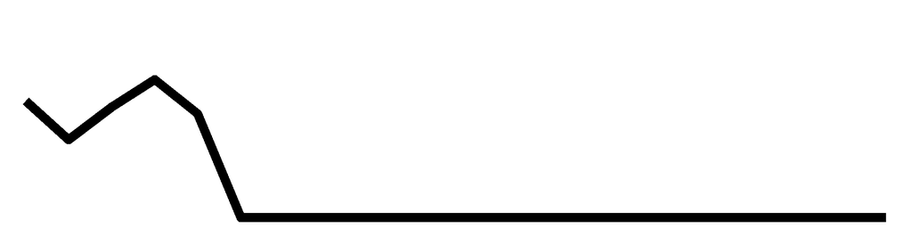

Caleb Doyle

9

NA

NA

NA

NA

NA

NA

6

NA

NA

NA

NA

NA

NA

NA

NA

NA

NA

NA

NA

NA

0

2

0.5000

0.0476

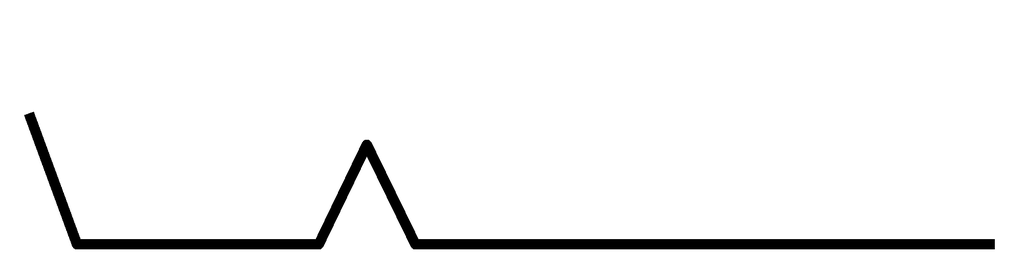

Sydney Johnson

NA

NA

NA

NA

NA

NA

NA

6

NA

NA

NA

NA

NA

NA

NA

NA

NA

NA

NA

NA

NA

0

1

0.4286

0.0204

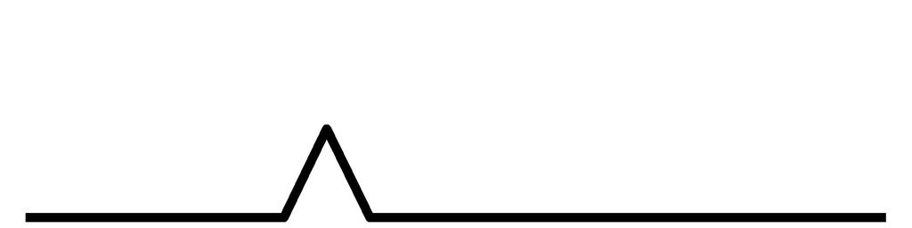

Congrats Luca Testa for having the best cadet picks this week, with a correct percentage of 1, Congrats John White for having the best cadet picks this week, with a correct percentage of 1, Congrats Gabriela Peralta for having the best cadet picks this week, with a correct percentage of 1, Congrats Sidney Cash for having the best cadet picks this week, with a correct percentage of 1

| Name | Week 1 | Week 2 | Week 3 | Week 4 | Week 5 | Week 6 | Week 7 | Week 8 | Week 9 | Week 10 | Week 11 | Week 12 | Week 13 | Week 14 | Week 15 | Week 16 | Week 17 | Week 18 | Week 19 | Week 20 | Week 21 | Percent | Weeks Picked | Season Percent | Adj Season Percent | Season Trend |
| --- | --- | --- | --- | --- | --- | --- | --- | --- | --- | --- | --- | --- | --- | --- | --- | --- | --- | --- | --- | --- | --- | --- | --- | --- | --- | --- |
| Luca Testa | NA | NA | 10 | NA | NA | NA | NA | NA | NA | NA | NA | NA | NA | NA | NA | NA | NA | NA | NA | NA | 1 | 1 | 2 | 0.6875 | 0.0655 |  |
| John White | 10 | 11 | 10 | 8 | 12 | 9 | 11 | 6 | 9 | 9 | 8 | 10 | 8 | 11 | 10 | 10 | 12 | 6 | 2 | 1 | 1 | 1 | 21 | 0.6566 | 0.6566 |  |
| Gabriela Peralta | 11 | 8 | 9 | NA | 8 | 8 | 10 | 6 | NA | 8 | 6 | 10 | 12 | NA | 12 | NA | NA | 4 | 3 | 1 | 1 | 1 | 16 | 0.6158 | 0.4692 |  |
| Sidney Cash | 10 | 10 | NA | 10 | NA | 8 | 8 | 7 | 11 | 8 | 5 | 10 | 10 | 8 | NA | NA | NA | NA | NA | 2 | 1 | 1 | 14 | 0.6034 | 0.4023 |  |
| Caroline Swenson | 8 | 12 | 11 | 13 | 7 | 8 | 10 | NA | 8 | 9 | 8 | NA | 12 | 11 | 12 | 8 | 13 | 4 | 3 | 1 | 0 | 0 | 19 | 0.6723 | 0.6083 |  |
| Paige Lennon | NA | NA | NA | 11 | 10 | 8 | 11 | 8 | 6 | 8 | 6 | 9 | 11 | 10 | 11 | NA | NA | NA | NA | NA | 0 | 0 | 13 | 0.6229 | 0.3856 |  |
| Sydney Shannon | 10 | 9 | 8 | 9 | 8 | 7 | 9 | 5 | 8 | 10 | 8 | 10 | 11 | 10 | 11 | 12 | 12 | 4 | 3 | 1 | 0 | 0 | 21 | 0.6226 | 0.6226 |  |
| Thomas Bizub | 10 | 14 | 8 | 11 | 8 | 9 | 10 | 8 | 10 | 12 | 9 | 11 | 9 | 10 | NA | NA | NA | NA | NA | NA | NA | 0 | 14 | 0.678 | 0.452 |  |
| Amadou Bah | 9 | NA | NA | NA | NA | NA | NA | NA | NA | NA | NA | NA | NA | NA | NA | 12 | NA | NA | NA | NA | NA | 0 | 2 | 0.6774 | 0.0645 |  |
| Kieran Place | 12 | 11 | 8 | NA | 10 | 10 | 9 | NA | NA | NA | NA | NA | NA | NA | NA | NA | NA | NA | NA | NA | NA | 0 | 6 | 0.6742 | 0.1926 |  |
| Laurence Dowd | 10 | 10 | 10 | 9 | 10 | NA | 12 | NA | 10 | 8 | 7 | NA | 10 | NA | NA | NA | NA | NA | NA | NA | NA | 0 | 10 | 0.6575 | 0.3131 |  |
| Joshua Loyd | 11 | 9 | 8 | NA | 6 | 9 | NA | 6 | 10 | 8 | NA | 10 | 9 | 11 | 12 | 12 | 13 | 3 | NA | NA | NA | 0 | 15 | 0.6343 | 0.4531 |  |
| Jonathan Kemp | 10 | 10 | NA | NA | 11 | 10 | 11 | 7 | 8 | 6 | 8 | 12 | 8 | 9 | NA | NA | NA | NA | NA | NA | NA | 0 | 12 | 0.6286 | 0.3592 |  |
| Zakai Bufkin | 8 | 11 | 7 | 9 | 8 | 10 | 9 | 7 | 9 | 9 | NA | 10 | NA | NA | NA | 12 | NA | NA | NA | NA | NA | 0 | 12 | 0.6158 | 0.3519 |  |
| Christopher Erb | 9 | 9 | 7 | 11 | 9 | 11 | 8 | 11 | 10 | 9 | 5 | 10 | 9 | 8 | NA | NA | NA | NA | NA | NA | NA | 0 | 14 | 0.6146 | 0.4097 |  |
| Victor Olawale-Apanpa | 8 | NA | 10 | NA | 10 | NA | 10 | 7 | 7 | 9 | 6 | 11 | 10 | NA | NA | NA | NA | NA | NA | NA | NA | 0 | 10 | 0.6069 | 0.289 |  |
| Cameron Patterson | 11 | 9 | 8 | NA | NA | NA | NA | NA | NA | NA | NA | NA | NA | NA | NA | NA | NA | NA | NA | NA | NA | 0 | 3 | 0.5957 | 0.0851 |  |
| Joshua Gilliard | 9 | 8 | 9 | 10 | 10 | 7 | 10 | 7 | 5 | 8 | NA | 10 | 10 | NA | NA | NA | NA | NA | NA | NA | NA | 0 | 12 | 0.5819 | 0.3325 |  |
| Margaret Williams | 9 | NA | NA | NA | NA | NA | NA | NA | NA | NA | NA | NA | NA | NA | NA | NA | NA | NA | NA | NA | NA | 0 | 1 | 0.5625 | 0.0268 |  |
| Logan Kauina | 9 | NA | NA | NA | NA | NA | NA | NA | NA | NA | NA | NA | NA | NA | NA | NA | NA | NA | NA | NA | NA | 0 | 1 | 0.5625 | 0.0268 |  |
| Caleb John | NA | 9 | NA | NA | NA | NA | NA | NA | NA | NA | NA | NA | NA | NA | NA | NA | NA | NA | NA | NA | NA | 0 | 1 | 0.5625 | 0.0268 |  |
| Jay Hajost | 11 | 7 | 10 | NA | 6 | NA | NA | 7 | 9 | NA | NA | NA | NA | NA | NA | NA | NA | NA | NA | NA | NA | 0 | 6 | 0.5618 | 0.1605 |  |
| Ryan Jackovic | 11 | 10 | NA | 7 | 7 | 8 | 8 | 7 | NA | 4 | 5 | NA | 12 | 10 | NA | NA | NA | NA | NA | NA | NA | 0 | 11 | 0.5562 | 0.2913 |  |
| August Rannow | 9 | NA | NA | NA | 7 | NA | NA | NA | NA | NA | NA | NA | NA | NA | NA | NA | NA | NA | NA | NA | NA | 0 | 2 | 0.5333 | 0.0508 |  |
| Peter Digenan | 9 | 6 | 8 | 10 | 7 | NA | NA | NA | NA | NA | NA | NA | NA | NA | NA | NA | NA | NA | NA | NA | NA | 0 | 5 | 0.5263 | 0.1253 |  |
| Caleb Doyle | 9 | NA | NA | NA | NA | NA | NA | 6 | NA | NA | NA | NA | NA | NA | NA | NA | NA | NA | NA | NA | NA | 0 | 2 | 0.5 | 0.0476 |  |
| Sydney Johnson | NA | NA | NA | NA | NA | NA | NA | 6 | NA | NA | NA | NA | NA | NA | NA | NA | NA | NA | NA | NA | NA | 0 | 1 | 0.4286 | 0.0204 |  |

[figure not shown]

## Combined cadet and instructor prediction

This Week's Combined Cadet and Instructor Predictions

Week 21

| Game | Prediction | Winner | Correct | Correct Votes | Correct Percent |
| --- | --- | --- | --- | --- | --- |
| 1 | Tie | Tampa Bay Buccaneers | -- | 11 | 0.5 |

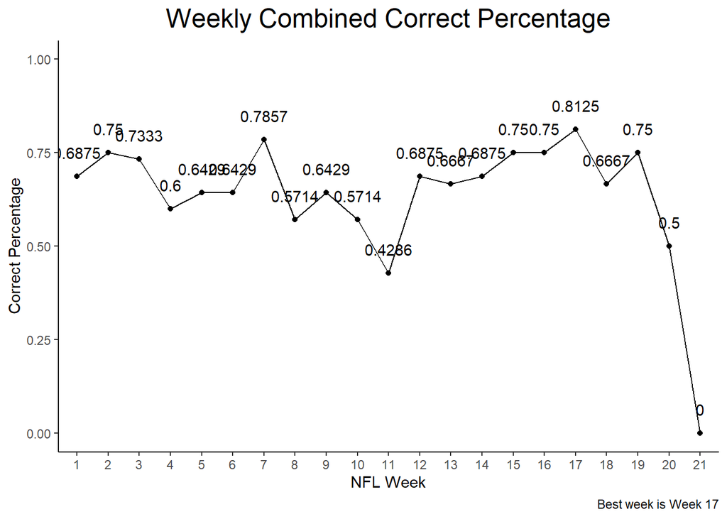

Our combined win percentage for the week is 0

Our season combined win percentage so far is 0.6792

22 total predictions this week

This Week's Matched Cadet and Instructor Predictions

Week 21

| Game | Prediction | Correct |
| --- | --- | --- |
| 1 | -- | -- |

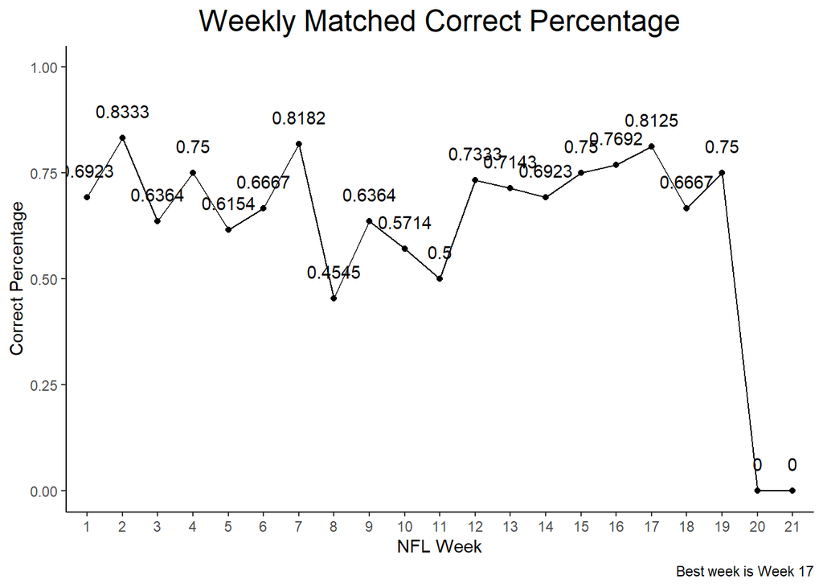

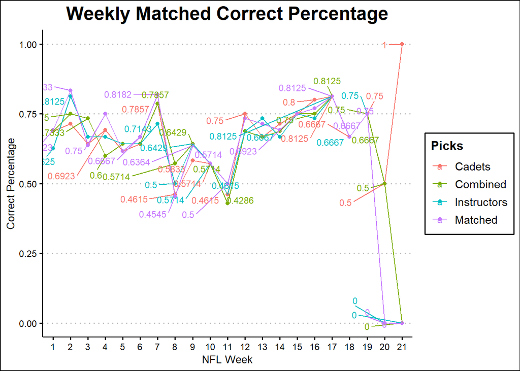